# Methods descriptives

Tim

2026-04-15

# Aim of this script

This script summarizes the methodological characteristics of the included item-content analyses (ICAs). It follows the order of the results chapter and keeps the workflow as linear as possible: load the data, create a few clearly separated working datasets, then calculate the descriptive summaries used in the text, tables, and figures.

# Step 1: Load packages

The analysis is based mainly on `tidyverse`. `janitor` is used to clean the column names, `here` handles file paths, and `officer` together with `flextable` is used for a Word export of the main tables.

```r
library(tidyverse)
library(janitor)
library(here)
library(scales)
library(officer)
library(flextable)
```

# Step 2: Define a few small helper functions

A small number of helper functions are used.

```r
std_text <- function(x) {
  x <- as.character(x)
  x <- stringr::str_to_lower(x)
  x <- stringr::str_squish(x)
  x
}

std_tags <- function(x) {
  x <- std_text(x)
  x <- stringr::str_replace_all(x, ",", ";")
  x <- stringr::str_replace_all(x, ";\\s*", ";")
  x
}

to_logical_strict <- function(x, colname = "unknown column") {
  x_chr <- as.character(x)
  x_std <- std_text(x_chr)

  true_vals <- c("true", "t", "yes", "y", "1")
  false_vals <- c("false", "f", "no", "n", "0")

  out <- dplyr::case_when(
    is.na(x_std) ~ NA,
    x_std %in% true_vals ~ TRUE,
    x_std %in% false_vals ~ FALSE,
    TRUE ~ NA
  )

  bad_vals <- unique(x_chr[!is.na(x_std) & !(x_std %in% c(true_vals, false_vals))])

  if (length(bad_vals) > 0) {
    stop(
      paste0(
        "Unexpected non-boolean value(s) in ", colname, ": ",
        paste(bad_vals, collapse = ", ")
      )
    )
  }

  out
}

prop_text <- function(n, d, accuracy = 0.1) {
  if (is.na(d) || d == 0) return(NA_character_)
  paste0(n, "/", d, " (", scales::percent(n / d, accuracy = accuracy), ")")
}

numeric_summary <- function(x) {
  x <- x[!is.na(x)]

  if (length(x) == 0) {
    return(tibble(
      n = 0,
      mean = NA_real_,
      sd = NA_real_,
      median = NA_real_,
      iqr = NA_real_,
      min = NA_real_,
      max = NA_real_,
      q25 = NA_real_,
      q75 = NA_real_
    ))
  }

  tibble(
    n = length(x),
    mean = mean(x),
    sd = sd(x),
    median = median(x),
    iqr = IQR(x),
    min = min(x),
    max = max(x),
    q25 = unname(quantile(x, 0.25)),
    q75 = unname(quantile(x, 0.75))
  )
}

ft_minimal <- function(df, caption = NULL) {
  ft <- flextable(df)

  if (!is.null(caption)) {
    ft <- set_caption(ft, caption)
  }

  ft %>%
    theme_booktabs() %>%
    autofit() %>%
    fontsize(size = 10, part = "all") %>%
    align(align = "left", part = "all") %>%
    valign(valign = "top", part = "all")
}
```

# Step 3: Define paths and load raw data

The CSV is read in as character data first. This avoids accidental coercion of semicolon-delimited fields such as `item_unit` or `percentage_reduction`.

```r
# Input file
path_in <- here::here("data", "processed", "ica_methods.csv")

if (!file.exists(path_in)) {
  stop("Processed analysis file not found: ", path_in)
}

# Output folders
output_dirs <- list(
  figures     = here::here("outputs", "figures"),
  tables_csv  = here::here("outputs", "tables", "csv"),
  tables_docx = here::here("outputs", "tables", "docx"),
  diagnostics = here::here("outputs", "diagnostics")
)

purrr::walk(output_dirs, dir.create, recursive = TRUE, showWarnings = FALSE)

# Read all columns as character first.
raw <- readr::read_csv(
  file = path_in,
  col_types = readr::cols(.default = readr::col_character()),
  na = c("", "NA", "N/A", "na", "n/a", "null", "NULL")
)

dat_raw <- raw %>%
  janitor::clean_names()

glimpse(dat_raw)
```

```
## Rows: 37
## Columns: 60
## $ study_id                             <chr> "Kook2024", "Vilar2022", "Chrobak…
## $ matrix                               <chr> "TRUE", "TRUE", "TRUE", "TRUE", "…
## $ n_scales                             <chr> "7", "18", "7", "7", "3", "6", "2…
## $ overarching_domain                   <chr> "psychological_condition", "psych…
## $ fields                               <chr> "clinical_psychopathology", "clin…
## $ administration_mode                  <chr> "self_report", "self_report", "mi…
## $ short_scales                         <chr> "FALSE", "FALSE", "TRUE", "TRUE",…
## $ population                           <chr> "children", "mixed", "adults", "m…
## $ scale_search                         <chr> "TRUE", "TRUE", "TRUE", "TRUE", "…
## $ database                             <chr> "google_scholar", "pubmed; psycin…
## $ prisma_a                             <chr> "TRUE", "TRUE", "TRUE", "TRUE", "…
## $ prisma                               <chr> "FALSE", "FALSE", "FALSE", "FALSE…
## $ inclusion_criteria_applicable        <chr> "TRUE", "TRUE", "TRUE", "TRUE", "…
```

[output cut: 47 more lines]

```r
required_cols <- c(
  "study_id",
  "n_scales",
  "population",
  "overarching_domain",
  "administration_mode",
  "scale_search",
  "database",
  "prisma_a",
  "prisma",
  "inclusion_binary",
  "clinical_relevance",
  "language_mentioned",
  "availability_mentioned",
  "release_date_mentioned",
  "frequency",
  "min_scale_citation",
  "exclusion_criteria",
  "item_unit",
  "percentage_reduction",
  "categorization_approach",
  "diagnostic_framework",
  "within_scale_item_collapse",
  "reverse_worded_items",
  "item_exclusions",
  "compound_items",
  "compound_items_codes",
  "idiosyncratic_items",
  "coding_team_reported",
  "initial_coding_team_size",
  "n_rater",
  "rater_expertise_mentioned",
  "blinded",
  "irr_reported",
  "codebook",
  "software_mentioned",
  "preregistered_rules",
  "coding_scheme_independent_mentioned",
  "disagreement_resolved_mentioned",
  "mean_overlap_nr",
  "min_overlap_nr",
  "max_overlap_nr",
  "length_correlation_noted",
  "correlation_lengthxmeanoverlap_type",
  "heterogeneity_emphasized",
  "overlap_reported",
  "noninterchangeability_emphasized",
  "recommend_careful_measure_selection",
  "recommend_measure_development",
  "ica_methods_problems",
  "matrix_source"
)

missing_required <- setdiff(required_cols, names(dat_raw))

if (length(missing_required) > 0) {
  stop(
    paste0(
      "The following required columns are missing: ",
      paste(missing_required, collapse = ", ")
    )
  )
}

if (nrow(dat_raw) != 37) {
  warning(
    paste0(
      "Expected 37 studies, but found ", nrow(dat_raw),
      ". Check whether the current CSV export has changed."
    )
  )
}
```

# Step 4: Create a few working datasets

To keep the workflow readable, the raw import is preserved and a few separate working datasets are created. The main idea: one dataset for logical variables, one for numeric variables, and one for standardized text fields.

## Step 4a: Logical variables

```r
logical_cols <- c(
  "matrix",
  "short_scales",
  "scale_search",
  "prisma_a",
  "prisma",
  "inclusion_criteria_applicable",
  "inclusion_binary",
  "clinical_relevance",
  "language_mentioned",
  "availability_mentioned",
  "release_date_mentioned",
  "frequency",
  "min_scale_citation",
  "exclusion_criteria",
  "multiple_analyses",
  "within_scale_item_collapse",
  "compound_items",
  "idiosyncratic_items",
  "reverse_worded_items",
  "coding_team_reported",
  "rater_expertise_mentioned",
  "blinded",
  "codebook",
  "software_mentioned",
  "item_exclusions",
  "irr_reported",
  "preregistered_rules",
  "coding_scheme_independent_mentioned",
  "mean_overlap",
  "min_overlap",
  "max_overlap",
  "length_correlation_noted",
  "disagreement_resolved_mentioned",
  "heterogeneity_emphasized",
  "noninterchangeability_emphasized",
  "recommend_careful_measure_selection",
  "recommend_measure_development",
  "ica_methods_problems"
)

logical_cols_present <- intersect(logical_cols, names(dat_raw))

dat_logical <- dat_raw

for (col in logical_cols_present) {
  dat_logical[[col]] <- to_logical_strict(dat_logical[[col]], colname = col)
}
```

## Step 4b: Numeric variables

Only variables that are clearly numeric are parsed here. The semicolon-delimited reduction field is deliberately left untouched and handled later at the analysis level.

```r
dat_num <- dat_raw %>%
  mutate(
    n_scales = readr::parse_number(n_scales),
    initial_coding_team_size = readr::parse_number(initial_coding_team_size),
    n_rater = readr::parse_number(n_rater),
    mean_overlap_nr = readr::parse_number(mean_overlap_nr),
    min_overlap_nr = readr::parse_number(min_overlap_nr),
    max_overlap_nr = readr::parse_number(max_overlap_nr)
  )
```

## Step 4c: Standardized text and tag fields

```r
dat_text <- dat_raw %>%
  mutate(
    population = std_text(population),
    overarching_domain = std_text(overarching_domain),
    administration_mode = std_text(administration_mode),
    categorization_approach = std_text(categorization_approach),
    compound_items_codes = std_text(compound_items_codes),
    software_used = std_text(software_used),
    matrix_source = std_text(matrix_source),
    database = std_tags(database),
    item_unit = std_tags(item_unit),
    diagnostic_framework = std_tags(diagnostic_framework)
  )
```

# Step 5: Overview of included ICAs

This section summarizes the broad descriptive characteristics of the included studies.

## Step 5a: Domain, administration mode, and population

```r
tab_population <- dat_text %>%
  count(population, name = "n") %>%
  mutate(
    `Proportion (n/N)` = paste0(n, "/", sum(n)),
    Percent = scales::percent(n / sum(n), accuracy = 0.1)) %>%
  arrange(desc(n))

tab_overarching_domain <- dat_text %>%
  count(overarching_domain, name = "n") %>%
  mutate(percent = scales::percent(n / sum(n), accuracy = 0.1)) %>%
  arrange(desc(n))

tab_administration_mode <- dat_text %>%
  count(administration_mode, name = "n") %>%
  mutate(
   `Proportion (n/N)` = paste0(n, "/", sum(n)),
    Percent = scales::percent(n / sum(n), accuracy = 0.1)) %>%
  arrange(desc(n))

tab_population
```

```
## # A tibble: 5 × 4
##   population         n `Proportion (n/N)` Percent
##   <chr>          <int> <chr>              <chr>
## 1 adults            20 20/37              54.1%
## 2 mixed             11 11/37              29.7%
## 3 children           4 4/37               10.8%
## 4 adolescents        1 1/37               2.7%
## 5 indeterminable     1 1/37               2.7%
```

```r
tab_overarching_domain
```

```
## # A tibble: 4 × 3
##   overarching_domain          n percent
##   <chr>                   <int> <chr>
## 1 psychological_condition    16 43.2%
## 2 transdiagnostic_feature    11 29.7%
## 3 other                       6 16.2%
## 4 medical_condition           4 10.8%
```

```r
tab_administration_mode
```

```
## # A tibble: 6 × 4
##   administration_mode      n `Proportion (n/N)` Percent
##   <chr>                <int> <chr>              <chr>
## 1 self_report             23 23/37              62.2%
## 2 mixed                    7 7/37               18.9%
## 3 indeterminable           2 2/37               5.4%
## 4 parent_report            2 2/37               5.4%
## 5 structured_interview     2 2/37               5.4%
## 6 observer_report          1 1/37               2.7%
```

## Step 5b: Number of scales per study

A second summary excludes the two broad mapping studies with exceptionally large instrument sets.

```r
n_scales_full <- numeric_summary(dat_num$n_scales)

exclude_ids <- c("Newson2020", "Linton2016")

n_scales_excluded <- dat_num %>%
  filter(!study_id %in% exclude_ids) %>%
  pull(n_scales) %>%
  numeric_summary()

n_scales_full
```

```
## # A tibble: 1 × 9
##       n  mean    sd median   iqr   min   max   q25   q75
##   <int> <dbl> <dbl>  <dbl> <dbl> <dbl> <dbl> <dbl> <dbl>
## 1    37  16.5  24.3     10     7     3   126     7    14
```

```r
n_scales_excluded
```

```
## # A tibble: 1 × 9
##       n  mean    sd median   iqr   min   max   q25   q75
##   <int> <dbl> <dbl>  <dbl> <dbl> <dbl> <dbl> <dbl> <dbl>
## 1    35  11.0  6.25      9   5.5     3    26     7  12.5
```

# Step 6: Scale search and selection transparency

This section summarizes whether studies actively assembled instrument sets, whether PRISMA-type reporting was used when applicable, which information sources were reported, and how selection criteria were documented.

## Step 6a: Basic binary summaries relevant to the search process

```r
scale_search_n <- sum(dat_logical$scale_search == TRUE, na.rm = TRUE)
scale_search_d <- sum(!is.na(dat_logical$scale_search))

prisma_applicable_n <- sum(dat_logical$prisma_a == TRUE, na.rm = TRUE)
prisma_applicable_d <- sum(!is.na(dat_logical$prisma_a))

prisma_reported_n <- dat_logical %>%
  filter(prisma_a == TRUE) %>%
  summarise(n = sum(prisma == TRUE, na.rm = TRUE)) %>%
  pull(n)

prisma_reported_d <- dat_logical %>%
  filter(prisma_a == TRUE) %>%
  summarise(n = sum(!is.na(prisma))) %>%
  pull(n)

search_summary <- tibble(
  indicator = c(
    "Scale search/manual selection",
    "PRISMA applicable",
    "PRISMA reported among applicable studies"
  ),
  n = c(scale_search_n, prisma_applicable_n, prisma_reported_n),
  denominator = c(scale_search_d, prisma_applicable_d, prisma_reported_d),
  report = c(
    prop_text(scale_search_n, scale_search_d),
    prop_text(prisma_applicable_n, prisma_applicable_d),
    prop_text(prisma_reported_n, prisma_reported_d)
  )
)

search_summary
```

```
## # A tibble: 3 × 4
##   indicator                                    n denominator report
##   <chr>                                    <int>       <int> <chr>
## 1 Scale search/manual selection               32          37 32/37 (86.5%)
## 2 PRISMA applicable                           32          37 32/37 (86.5%)
## 3 PRISMA reported among applicable studies    14          32 14/32 (43.8%)
```

## Step 6b: Database reporting and search breadth

Databases are stored as semicolon-delimited fields. The code below first expands them into a long table and then summarizes both source prevalence and the number of sources per study.

```r
db_long <- dat_text %>%
  select(study_id, database) %>%
  separate_rows(database, sep = ";") %>%
  mutate(database = stringr::str_trim(database)) %>%
  filter(!is.na(database), database != "") %>%
  distinct(study_id, database)

db_usage <- db_long %>%
  count(database, name = "n") %>%
  mutate(percent = scales::percent(n / nrow(dat_text), accuracy = 0.1)) %>%
  arrange(desc(n), database)

db_breadth <- db_long %>%
  filter(database != "indeterminable") %>%
  count(study_id, name = "n_sources")

db_breadth_summary <- tibble(
  n_scale_search_studies = sum(dat_logical$scale_search == TRUE, na.rm = TRUE),
  n_with_database_info = nrow(db_breadth),
  mean = mean(db_breadth$n_sources),
  median = median(db_breadth$n_sources),
  min = min(db_breadth$n_sources),
  max = max(db_breadth$n_sources),
  n_single_database = sum(db_breadth$n_sources == 1)
)

db_breadth_distribution <- db_breadth %>%
  count(n_sources, name = "n_studies") %>%
  mutate(percent = scales::percent(n_studies / sum(n_studies), accuracy = 0.1)) %>%
  arrange(n_sources)

db_usage
```

```
## # A tibble: 17 × 3
##    database                   n percent
##    <chr>                  <int> <chr>
##  1 psycinfo                  13 35.1%
##  2 pubmed                    11 29.7%
##  3 indeterminable             9 24.3%
##  4 google_scholar             8 21.6%
##  5 web_of_science             7 18.9%
##  6 embase                     6 16.2%
##  7 medline                    5 13.5%
##  8 cinahl                     3 8.1%
##  9 eric                       3 8.1%
## 10 scopus                     3 8.1%
## 11 sociological_abstracts     2 5.4%
## 12 cosmin                     1 2.7%
## 13 eprovide                   1 2.7%
## 14 proquest                   1 2.7%
## 15 psycarticles               1 2.7%
## 16 ptsdpubs                   1 2.7%
## 17 sciencedirect              1 2.7%
```

```r
db_breadth_summary
```

```
## # A tibble: 1 × 7
##   n_scale_search_studies n_with_database_info  mean median   min   max
##                    <int>                <int> <dbl>  <int> <int> <int>
## 1                     32                   23  2.91      2     1     7
## # ℹ 1 more variable: n_single_database <int>
```

```r
db_breadth_distribution
```

```
## # A tibble: 6 × 3
##   n_sources n_studies percent
##       <int>     <int> <chr>
## 1         1         8 34.8%
## 2         2         4 17.4%
## 3         3         2 8.7%
## 4         4         5 21.7%
## 5         6         3 13.0%
## 6         7         1 4.3%
```

## Step 6c: Selection criteria format

This summary is conditional on studies that conducted a scale search.

```r
dat_search <- dat_logical %>%
  filter(scale_search == TRUE)

criteria_combo_block <- dat_search %>%
  filter(!is.na(inclusion_binary), !is.na(exclusion_criteria)) %>%
  mutate(
    selection_criteria_format = case_when(
      inclusion_binary == TRUE & exclusion_criteria == TRUE ~ "Both inclusion & exclusion",
      inclusion_binary == TRUE & exclusion_criteria == FALSE ~ "Inclusion only",
      inclusion_binary == FALSE & exclusion_criteria == TRUE ~ "Exclusions only",
      inclusion_binary == FALSE & exclusion_criteria == FALSE ~ "Neither inclusion nor exclusion"
    )
  ) %>%
  count(selection_criteria_format, name = "n") %>%
  mutate(
    `Proportion (n/N)` = paste0(n, "/", sum(n)),
    Percent = scales::percent(n / sum(n), accuracy = 0.1)
  ) %>%
  rename(`Selection criteria format` = selection_criteria_format) %>%
  arrange(desc(n))

criteria_combo_block
```

```
## # A tibble: 4 × 4
##   `Selection criteria format`         n `Proportion (n/N)` Percent
##   <chr>                           <int> <chr>              <chr>
## 1 Both inclusion & exclusion         21 21/32              65.6%
## 2 Inclusion only                      7 7/32               21.9%
## 3 Neither inclusion nor exclusion     3 3/32               9.4%
## 4 Exclusions only                     1 1/32               3.1%
```

## Step 6d: Specific inclusion criteria

This summary is restricted further to studies that reported inclusion criteria.

```r
dat_inclusion <- dat_search %>%
  filter(inclusion_binary == TRUE)

n_inclusion_studies <- nrow(dat_inclusion)

criteria_inclusion_block <- tibble(
  criterion = c(
    "language",
    "frequency",
    "availability",
    "release date/recency",
    "clinical relevance",
    "minimum citation threshold"
  ),
  n = c(
    sum(dat_inclusion$language_mentioned == TRUE, na.rm = TRUE),
    sum(dat_inclusion$frequency == TRUE, na.rm = TRUE),
    sum(dat_inclusion$availability_mentioned == TRUE, na.rm = TRUE),
    sum(dat_inclusion$release_date_mentioned == TRUE, na.rm = TRUE),
    sum(dat_inclusion$clinical_relevance == TRUE, na.rm = TRUE),
    sum(dat_inclusion$min_scale_citation == TRUE, na.rm = TRUE)
  )
) %>%
  mutate(
    `Proportion (n/N)` = paste0(n, "/", n_inclusion_studies),
    Percent = scales::percent(n / n_inclusion_studies, accuracy = 0.1)
  ) %>%
  rename(`Inclusion criteria` = criterion) %>%
  arrange(desc(n))

criteria_inclusion_block
```

```
## # A tibble: 6 × 4
##   `Inclusion criteria`           n `Proportion (n/N)` Percent
##   <chr>                      <int> <chr>              <chr>
## 1 language                      17 17/28              60.7%
## 2 frequency                     14 14/28              50.0%
## 3 availability                   8 8/28               28.6%
## 4 release date/recency           8 8/28               28.6%
## 5 clinical relevance             6 6/28               21.4%
## 6 minimum citation threshold     4 4/28               14.3%
```

# Step 7: Unit of comparison and percentage reduction

This section is handled on the analysis level because some studies report more than one overlap analysis. The key point is that `item_unit` and `percentage_reduction` must be split into aligned tokens within each study.

## Step 7a: Expand to an analysis-level dataset

```r
analysis_long <- dat_raw %>%
  transmute(
    study_id,
    item_unit = std_tags(item_unit),
    percentage_reduction
  ) %>%
  rowwise() %>%
  mutate(
    unit_list = list({
      x <- item_unit
      if (is.na(x) || x == "") character(0) else stringr::str_split(x, ";", simplify = FALSE)[[1]]
    }),
    reduction_list = list({
      x <- percentage_reduction
      if (is.na(x) || x == "") {
        numeric(0)
      } else {
        vals <- stringr::str_split(as.character(x), ";", simplify = FALSE)[[1]]
        vals <- stringr::str_trim(vals)
        vals <- stringr::str_replace_all(vals, ",", ".")
        readr::parse_number(vals)
      }
    }),
    n_units = length(unit_list),
    n_reduction = length(reduction_list)
  ) %>%
  ungroup()

length_mismatch <- analysis_long %>%
  filter(n_reduction > 0, n_units != n_reduction)

if (nrow(length_mismatch) > 0) {
  warning(
    paste0(
      "Some studies have unequal numbers of item_unit and percentage_reduction entries: ",
      paste(length_mismatch$study_id, collapse = ", ")
    )
  )
}

analysis_long <- analysis_long %>%
  select(study_id, unit_list, reduction_list) %>%
  mutate(row_id = row_number()) %>%
  unnest_longer(unit_list, indices_to = "idx") %>%
  rename(unit_token = unit_list) %>%
  left_join(
    analysis_long %>%
      select(study_id, reduction_list) %>%
      mutate(row_id = row_number()) %>%
      unnest_longer(reduction_list, indices_to = "idx") %>%
      rename(percentage_reduction_num = reduction_list),
    by = c("study_id", "row_id", "idx")
  ) %>%
  select(-row_id) %>%
  mutate(unit_token = stringr::str_trim(unit_token))

if (nrow(analysis_long) != 44) {
  warning(
    paste0(
      "Expected 44 analysis-level rows based on item_unit. Found ", nrow(analysis_long), "."
    )
  )
}

analysis_long
```

```
## # A tibble: 44 × 5
##    study_id     unit_token        idx reduction_list percentage_reduction_num
##    <chr>        <chr>           <int> <list>                            <dbl>
##  1 Kook2024     criterion_level     1 <dbl [1]>                          81.7
##  2 Vilar2022    symptom_level       1 <dbl [2]>                          90.2
##  3 Vilar2022    category_level      2 <dbl [2]>                          98.7
##  4 Chrobak2018  symptom_level       1 <dbl [1]>                          50
##  5 Visontay2019 symptom_level       1 <dbl [1]>                          73.8
##  6 Hendriks2020 symptom_level       1 <dbl [1]>                          52.7
##  7 Castro2023   symptom_level       1 <dbl [1]>                          60.7
##  8 Backhaus2022 category_level      1 <dbl [1]>                          91.0
##  9 Ong2023      symptom_level       1 <dbl [1]>                          75.5
## 10 Martin2022   item_level          1 <dbl [1]>                           0
## # ℹ 34 more rows
```

## Step 7b: Unit-of-comparison counts

```r
unit_counts_total_analyses <- analysis_long %>%
  count(unit_token, name = "n") %>%
  mutate(percent = scales::percent(n / sum(n), accuracy = 0.1)) %>%
  arrange(desc(n))

unit_counts_total_analyses
```

```
## # A tibble: 5 × 3
##   unit_token          n percent
##   <chr>           <int> <chr>
## 1 symptom_level      28 63.6%
## 2 category_level     12 27.3%
## 3 criterion_level     2 4.5%
## 4 item_level          1 2.3%
## 5 semantic_level      1 2.3%
```

## Step 7c: Percentage reduction summaries

```r
reduction_summary <- analysis_long %>%
  filter(!is.na(percentage_reduction_num)) %>%
  pull(percentage_reduction_num) %>%
  numeric_summary() %>%
  mutate(n_total_analyses = nrow(analysis_long)) %>%
  relocate(n_total_analyses)

reduction_by_unit_token <- analysis_long %>%
  filter(!is.na(percentage_reduction_num)) %>%
  group_by(unit_token) %>%
  summarise(
    n = n(),
    mean = mean(percentage_reduction_num),
    sd = sd(percentage_reduction_num),
    median = median(percentage_reduction_num),
    iqr = IQR(percentage_reduction_num),
    min = min(percentage_reduction_num),
    max = max(percentage_reduction_num),
    q25 = unname(quantile(percentage_reduction_num, 0.25)),
    q75 = unname(quantile(percentage_reduction_num, 0.75)),
    .groups = "drop"
  ) %>%
  arrange(desc(n)) %>%
  mutate(
    across(c(mean, sd, median, iqr), ~ round(.x, 2)),
    across(c(min, max, q25, q75), ~ round(.x, 1))
  )

reduction_summary
```

```
## # A tibble: 1 × 10
##   n_total_analyses     n  mean    sd median   iqr   min   max   q25   q75
##              <int> <int> <dbl> <dbl>  <dbl> <dbl> <dbl> <dbl> <dbl> <dbl>
## 1               44    42  73.2  23.0   79.3  32.3     0  99.6  58.4  90.8
```

```r
reduction_by_unit_token
```

```
## # A tibble: 5 × 10
##   unit_token          n  mean    sd median   iqr   min   max   q25   q75
##   <chr>           <int> <dbl> <dbl>  <dbl> <dbl> <dbl> <dbl> <dbl> <dbl>
## 1 symptom_level      27  68.4 19.0    68.8 26.8   32    96.7  56.7  83.5
## 2 category_level     11  92.2  7.13   91.0  9.41  75.8  99.6  89.1  98.5
## 3 criterion_level     2  88.3  9.28   88.3  6.56  81.7  94.9  85    91.6
## 4 item_level          1   0   NA       0    0      0     0     0     0
## 5 semantic_level      1  36.6 NA      36.6  0     36.6  36.6  36.6  36.6
```

## Step 7d: Plotting the two most common unit types

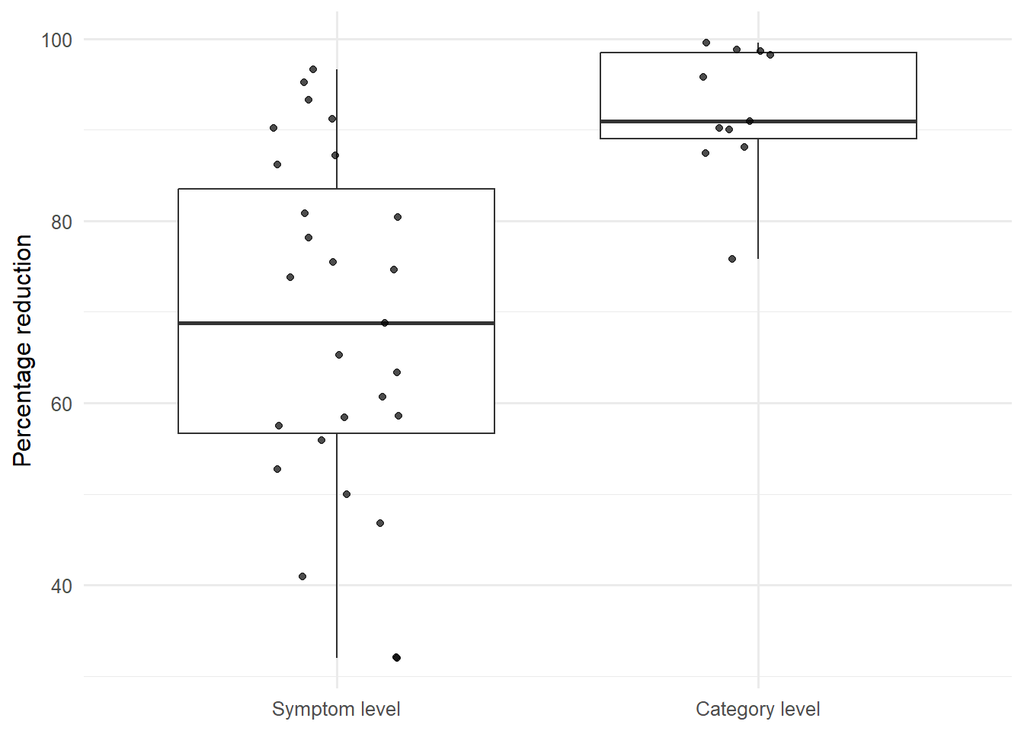

```r
plot_reduction <- analysis_long %>%
  filter(unit_token %in% c("symptom_level", "category_level")) %>%
  filter(!is.na(percentage_reduction_num)) %>%
  mutate(unit_token = factor(unit_token, levels = c("symptom_level", "category_level")))

fig_reduction_by_unit <- ggplot(plot_reduction, aes(x = unit_token, y = percentage_reduction_num)) +
  geom_boxplot(outlier.shape = NA) +
  geom_jitter(width = 0.15, height = 0, alpha = 0.7) +
  scale_x_discrete(labels = c(
    symptom_level = "Symptom level",
    category_level = "Category level"
  )) +
  labs(x = NULL, y = "Percentage reduction") +
  theme_minimal(base_size = 12)

fig_reduction_by_unit
```

```r
ggsave(
  filename = file.path(output_dirs$figures, "fig_percentage_reduction_by_unit.png"),
  plot = fig_reduction_by_unit,
  width = 6.5,
  height = 4.5,
  dpi = 300,
  bg = "white"
)
```

# Step 8: Categorization approach and diagnostic framework

The categorization approach is a single-value field. The diagnostic-framework field can contain more than one tag per study.

```r
tab_categorization_approach <- dat_text %>%
  count(categorization_approach, name = "n") %>%
  mutate(percent = scales::percent(n / sum(n), accuracy = 0.1)) %>%
  arrange(desc(n))

diag_long <- dat_text %>%
  select(study_id, diagnostic_framework) %>%
  separate_rows(diagnostic_framework, sep = ";") %>%
  mutate(diagnostic_framework = stringr::str_trim(diagnostic_framework)) %>%
  filter(!is.na(diagnostic_framework), diagnostic_framework != "") %>%
  distinct(study_id, diagnostic_framework)

diag_fw_usage <- diag_long %>%
  count(diagnostic_framework, name = "n") %>%
  mutate(percent = scales::percent(n / nrow(dat_text), accuracy = 0.1)) %>%
  arrange(desc(n), diagnostic_framework)

diag_fw_breadth <- diag_long %>%
  count(study_id, name = "n_frameworks")

diag_fw_breadth_summary <- tibble(
  n_coded = nrow(diag_fw_breadth),
  mean = mean(diag_fw_breadth$n_frameworks),
  median = median(diag_fw_breadth$n_frameworks),
  min = min(diag_fw_breadth$n_frameworks),
  max = max(diag_fw_breadth$n_frameworks)
)

tab_categorization_approach
```

```
## # A tibble: 3 × 3
##   categorization_approach     n percent
##   <chr>                   <int> <chr>
## 1 bottom_up                  27 73.0%
## 2 mixed                       5 13.5%
## 3 top_down                    5 13.5%
```

```r
diag_fw_usage
```

```
## # A tibble: 6 × 3
##   diagnostic_framework     n percent
##   <chr>                <int> <chr>
## 1 none                    18 48.6%
## 2 dsm                     13 35.1%
## 3 other                    4 10.8%
## 4 icd                      2 5.4%
## 5 who_definition           2 5.4%
## 6 guideline                1 2.7%
```

```r
diag_fw_breadth_summary
```

```
## # A tibble: 1 × 5
##   n_coded  mean median   min   max
##     <int> <dbl>  <int> <int> <int>
## 1      37  1.08      1     1     2
```

# Step 9: Item preprocessing and transformation decisions

This section reports the prevalence of the main preprocessing and transformation decisions. The compound-item subrows use a conditional denominator restricted to studies that mentioned compound items.

```r
n_total_studies <- nrow(dat_logical)
n_compound <- sum(dat_logical$compound_items == TRUE, na.rm = TRUE)

tab_transform_main <- tibble(
  Decision = c(
    "Within-scale item collapsing",
    "Reverse-worded items collapsed",
    "Item exclusions reported",
    "Idiosyncratic/unique items discussed",
    "Compound items discussed"
  ),
  n = c(
    sum(dat_logical$within_scale_item_collapse == TRUE, na.rm = TRUE),
    sum(dat_logical$reverse_worded_items == TRUE, na.rm = TRUE),
    sum(dat_logical$item_exclusions == TRUE, na.rm = TRUE),
    sum(dat_logical$idiosyncratic_items == TRUE, na.rm = TRUE),
    sum(dat_logical$compound_items == TRUE, na.rm = TRUE)
  )
) %>%
  mutate(
    `Proportion (n/N)` = paste0(n, "/", n_total_studies),
    Percent = scales::percent(n / n_total_studies, accuracy = 0.1)
  )

tab_compound_sub <- dat_text %>%
  select(study_id, compound_items_codes) %>%
  left_join(dat_logical %>% select(study_id, compound_items), by = "study_id") %>%
  filter(compound_items == TRUE) %>%
  filter(!is.na(compound_items_codes), compound_items_codes != "") %>%
  count(compound_items_codes, name = "n") %>%
  mutate(
    Decision = case_when(
      compound_items_codes == "multi_coded" ~ "  ↳ Compound handling: multi-coded",
      compound_items_codes == "mono_coded" ~ "  ↳ Compound handling: mono-coded",
      compound_items_codes == "other" ~ "  ↳ Compound handling: other",
      TRUE ~ "  ↳ Compound handling: other/unclear"
    ),
    `Proportion (n/N)` = paste0(n, "/", n_compound),
    Percent = scales::percent(n / n_compound, accuracy = 0.1)
  ) %>%
  select(Decision, n, `Proportion (n/N)`, Percent) %>%
  arrange(desc(n))

tab_transformations <- bind_rows(tab_transform_main, tab_compound_sub)

tab_transformations
```

```
## # A tibble: 8 × 4
##   Decision                                   n `Proportion (n/N)` Percent
##   <chr>                                  <int> <chr>              <chr>
## 1 "Within-scale item collapsing"            16 16/37              43.2%
## 2 "Reverse-worded items collapsed"           7 7/37               18.9%
## 3 "Item exclusions reported"                13 13/37              35.1%
## 4 "Idiosyncratic/unique items discussed"    26 26/37              70.3%
## 5 "Compound items discussed"                24 24/37              64.9%
## 6 "  ↳ Compound handling: multi-coded"      20 20/24              83.3%
## 7 "  ↳ Compound handling: mono-coded"        2 2/24               8.3%
## 8 "  ↳ Compound handling: other"             2 2/24               8.3%
```

# Step 10: Coding workflow, reliability, and reproducibility

This section summarizes the currently extracted coding-workflow variables and the additional reproducibility indicators already in the dataset.

## Step 10a: Coding-team summary values

```r
coding_team_summary <- tibble(
  Indicator = "Coding team reported",
  n = sum(dat_logical$coding_team_reported == TRUE, na.rm = TRUE),
  denominator = sum(!is.na(dat_logical$coding_team_reported))
) %>%
  mutate(report = prop_text(n, denominator))

rater_expertise_summary <- tibble(
  Indicator = "Rater expertise mentioned",
  n = sum(dat_logical$rater_expertise_mentioned == TRUE, na.rm = TRUE),
  denominator = sum(!is.na(dat_logical$rater_expertise_mentioned))
) %>%
  mutate(report = prop_text(n, denominator))

blinded_summary <- tibble(
  Indicator = "Blinded",
  n = sum(dat_logical$blinded == TRUE, na.rm = TRUE),
  denominator = sum(!is.na(dat_logical$blinded))
) %>%
  mutate(report = prop_text(n, denominator))

initial_team_summary <- numeric_summary(dat_num$initial_coding_team_size)
n_rater_summary <- numeric_summary(dat_num$n_rater)

coding_team_summary
```

```
## # A tibble: 1 × 4
##   Indicator                n denominator report
##   <chr>                <int>       <int> <chr>
## 1 Coding team reported    28          37 28/37 (75.7%)
```

```r
rater_expertise_summary
```

```
## # A tibble: 1 × 4
##   Indicator                     n denominator report
##   <chr>                     <int>       <int> <chr>
## 1 Rater expertise mentioned     8          37 8/37 (21.6%)
```

```r
blinded_summary
```

```
## # A tibble: 1 × 4
##   Indicator     n denominator report
##   <chr>     <int>       <int> <chr>
## 1 Blinded       2          37 2/37 (5.4%)
```

```r
initial_team_summary
```

```
## # A tibble: 1 × 9
##       n  mean    sd median   iqr   min   max   q25   q75
##   <int> <dbl> <dbl>  <dbl> <dbl> <dbl> <dbl> <dbl> <dbl>
## 1    28  2.29  1.56      2     1     1     7     1     2
```

```r
n_rater_summary
```

```
## # A tibble: 1 × 9
##       n  mean    sd median   iqr   min   max   q25   q75
##   <int> <dbl> <dbl>  <dbl> <dbl> <dbl> <dbl> <dbl> <dbl>
## 1    28  3.25  1.76      3     2     1     8     2     4
```

```r
tab_coding_desc <- bind_rows(rater_expertise_summary, blinded_summary)
tab_coding_desc
```

```
## # A tibble: 2 × 4
##   Indicator                     n denominator report
##   <chr>                     <int>       <int> <chr>
## 1 Rater expertise mentioned     8          37 8/37 (21.6%)
## 2 Blinded                       2          37 2/37 (5.4%)
```

```r
team_size_table <- tibble::tibble(
  metric = c("Initial coding team size", "Number of raters"),
  n = c(initial_team_summary$n, n_rater_summary$n),
  mean = c(initial_team_summary$mean, n_rater_summary$mean),
  sd = c(initial_team_summary$sd, n_rater_summary$sd),
  median = c(initial_team_summary$median, n_rater_summary$median),
  iqr = c(initial_team_summary$iqr, n_rater_summary$iqr),
  min = c(initial_team_summary$min, n_rater_summary$min),
  max = c(initial_team_summary$max, n_rater_summary$max)
) %>%
 mutate(
    across(c(mean, sd, median, iqr), ~ round(.x, 2)),
    across(c(n, min, max), ~ round(.x, 0))
  )

team_size_table
```

```
## # A tibble: 2 × 8
##   metric                       n  mean    sd median   iqr   min   max
##   <chr>                    <dbl> <dbl> <dbl>  <dbl> <dbl> <dbl> <dbl>
## 1 Initial coding team size    28  2.29  1.56      2     1     1     7
## 2 Number of raters            28  3.25  1.76      3     2     1     8
```

## Step 10b: Coding-team distributions

```r
initial_team_size_dist <- dat_num %>%
  filter(!is.na(initial_coding_team_size)) %>%
  count(initial_coding_team_size, name = "n") %>%
  mutate(
    percent = 100 * n / sum(n)
  ) %>%
  arrange(initial_coding_team_size) %>%
  mutate(
    percent = round(percent, 1)
  )

initial_team_size_dist
```

```
## # A tibble: 5 × 3
##   initial_coding_team_size     n percent
##                      <dbl> <int>   <dbl>
## 1                        1     8    28.6
## 2                        2    14    50
## 3                        3     3    10.7
## 4                        6     2     7.1
## 5                        7     1     3.6
```

```r
n_rater_size_dist <- dat_num %>%
  filter(!is.na(n_rater)) %>%
  count(n_rater, name = "n") %>%
  mutate(
    percent = 100 * n / sum(n)
  ) %>%
  arrange(n_rater) %>%
  mutate(
    percent = round(percent, 1)
  )

n_rater_size_dist
```

```
## # A tibble: 8 × 3
##   n_rater     n percent
##     <dbl> <int>   <dbl>
## 1       1     2     7.1
## 2       2    10    35.7
## 3       3     7    25
## 4       4     4    14.3
## 5       5     1     3.6
## 6       6     2     7.1
## 7       7     1     3.6
## 8       8     1     3.6
```

```r
coding_team_expansion <- dat_num %>%
  filter(!is.na(initial_coding_team_size), !is.na(n_rater)) %>%
  mutate(additional_raters = n_rater - initial_coding_team_size)

team_expansion_dist <- coding_team_expansion %>%
  count(additional_raters, name = "n") %>%
  mutate(
    percent = 100 * n / sum(n)
  ) %>%
  arrange(additional_raters) %>%
  mutate(
    percent = round(percent, 1)
  )

team_expansion_binary <- coding_team_expansion %>%
  mutate(expanded = additional_raters > 0) %>%
  count(expanded, name = "n") %>%
  mutate(
    percent = 100 * n / sum(n)
  ) %>%
  mutate(
    percent = round(percent, 1)
  )

team_expansion_binary
```

```
## # A tibble: 2 × 3
##   expanded     n percent
##   <lgl>    <int>   <dbl>
## 1 FALSE       13    46.4
## 2 TRUE        15    53.6
```

## Step 10c: Coding-team figures

```r
# Combining the two distributions for plotting
team_size_plot <- bind_rows(
  initial_team_size_dist %>%
    transmute(
      team_size = initial_coding_team_size,
      n,
      percent,
      type = "Initial coding team"
    ),
  n_rater_size_dist %>%
    transmute(
      team_size = n_rater,
      n,
      percent,
      type = "Total raters involved"
    )
)

team_size_plot
```

```
## # A tibble: 13 × 4
##    team_size     n percent type
##        <dbl> <int>   <dbl> <chr>
##  1         1     8    28.6 Initial coding team
##  2         2    14    50   Initial coding team
##  3         3     3    10.7 Initial coding team
##  4         6     2     7.1 Initial coding team
##  5         7     1     3.6 Initial coding team
##  6         1     2     7.1 Total raters involved
##  7         2    10    35.7 Total raters involved
##  8         3     7    25   Total raters involved
##  9         4     4    14.3 Total raters involved
## 10         5     1     3.6 Total raters involved
## 11         6     2     7.1 Total raters involved
## 12         7     1     3.6 Total raters involved
## 13         8     1     3.6 Total raters involved
```

```r
team_expansion_summary <- dat_num %>%
  filter(!is.na(initial_coding_team_size), !is.na(n_rater)) %>%
  mutate(expanded = n_rater > initial_coding_team_size) %>%
  summarise(
    n_expanded = sum(expanded),
    n_total = n(),
    percent_expanded = round(100 * n_expanded / n_total, 1)
  )

team_expansion_summary
```

```
## # A tibble: 1 × 3
##   n_expanded n_total percent_expanded
##        <int>   <int>            <dbl>
## 1         15      28             53.6
```

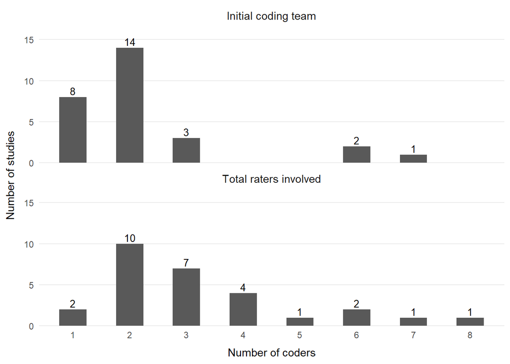

```r
#Faceted bar plot of coding-team distributions

team_dist_plot <- bind_rows(
  initial_team_size_dist %>%
    transmute(
      team_size = initial_coding_team_size,
      n,
      type = "Initial coding team"
    ),
  n_rater_size_dist %>%
    transmute(
      team_size = n_rater,
      n,
      type = "Total raters involved"
    )
) %>%
  mutate(
    team_size = as.integer(team_size)
  )

all_team_sizes <- seq(
  from = min(team_dist_plot$team_size, na.rm = TRUE),
  to = max(team_dist_plot$team_size, na.rm = TRUE)
)

team_dist_plot <- team_dist_plot %>%
  tidyr::complete(
    type,
    team_size = all_team_sizes,
    fill = list(n = 0)
  )

p_team_dist <- ggplot(team_dist_plot, aes(x = factor(team_size), y = n)) +
  geom_col(width = 0.48) +
  geom_text(
    aes(label = ifelse(n == 0, "", n)),
    vjust = -0.3,
    size = 3.5
  ) +
  facet_wrap(~ type, ncol = 1) +
  scale_y_continuous(
    limits = c(0, 16),
    breaks = c(0, 5, 10, 15),
    expand = expansion(mult = c(0, 0.05))
  ) +
  labs(
    x = "Number of coders",
    y = "Number of studies"
  ) +
  theme_minimal(base_size = 11) +
  theme(
    panel.grid.major.x = element_blank(),
    panel.grid.minor = element_blank(),
    strip.text = element_text(face = "plain", size = 11),
    strip.background = element_blank(),
    axis.title.x = element_text(margin = margin(t = 8)),
    axis.title.y = element_text(margin = margin(r = 8)),
    plot.title = element_blank()
  )

p_team_dist
```

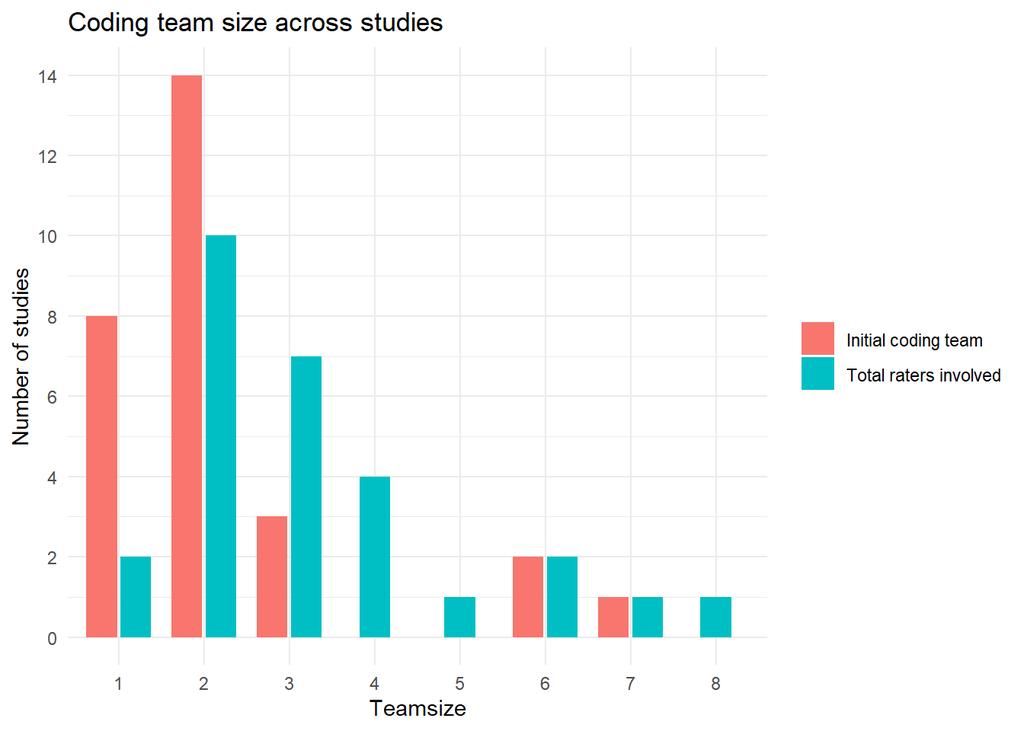

```r
# Figure: comparison of coding team sizes
p_team_size <- ggplot(team_size_plot, aes(x = factor(team_size), y = n, fill = type)) +
  geom_col(
    position = position_dodge2(width = 0.9, preserve = "single"),
    width = 0.8
  ) +
  labs(
    x = "Teamsize",
    y = "Number of studies",
    fill = NULL,
    title = "Coding team size across studies"
  ) +
  scale_y_continuous(breaks = seq(0, 20, by = 2)) +
  theme_minimal()
p_team_size
```

```r
ggsave(
  filename = file.path(output_dirs$figures, "team_distribution_plot_alt.png"),
  plot = p_team_size,
  width = 8.5,
  height = 4.5,
  bg = "white"
)

ggsave(
  filename = file.path(output_dirs$figures, "team_distribution_plot.png"),
  plot = p_team_dist,
  width = 6.5,
  height = 5.5,
  bg = "white"
)

team_transition_table <- dat_num %>%
  filter(!is.na(initial_coding_team_size), !is.na(n_rater)) %>%
  count(initial_coding_team_size, n_rater, name = "n") %>%
  arrange(initial_coding_team_size, n_rater)

team_transition_table
```

```
## # A tibble: 14 × 3
##    initial_coding_team_size n_rater     n
##                       <dbl>   <dbl> <int>
##  1                        1       1     2
##  2                        1       2     3
##  3                        1       3     1
##  4                        1       4     2
##  5                        2       2     7
##  6                        2       3     4
##  7                        2       4     1
##  8                        2       5     1
##  9                        2       6     1
## 10                        3       3     2
## 11                        3       4     1
## 12                        6       6     1
## 13                        6       8     1
## 14                        7       7     1
```

## Step 10d: Additional reliability indicators

```r
reliability_table <- tibble(
  Indicator = c(
    "Independent coding scheme mentioned",
    "Interrater reliability reported",
    "Disagreement resolved mentioned"
  ),
  `n (Studies)` = c(
    sum(dat_logical$coding_scheme_independent_mentioned == TRUE, na.rm = TRUE),
    sum(dat_logical$irr_reported == TRUE, na.rm = TRUE),
    sum(dat_logical$disagreement_resolved_mentioned == TRUE, na.rm = TRUE)
  ),
  denominator = c(
    sum(!is.na(dat_logical$coding_scheme_independent_mentioned)),
    sum(!is.na(dat_logical$irr_reported)),
    sum(!is.na(dat_logical$disagreement_resolved_mentioned))
  )
) %>%
  mutate(
    `Proportion (n/N)` = paste0(`n (Studies)`, "/", denominator),
    Percent = 100 * `n (Studies)` / denominator
  ) %>%
  mutate(
    Percent = paste0(round(Percent, 1), "%")
  ) %>%
  select(Indicator, `n (Studies)`, `Proportion (n/N)`, Percent)

reliability_table
```

```
## # A tibble: 3 × 4
##   Indicator                           `n (Studies)` `Proportion (n/N)` Percent
##   <chr>                                       <int> <chr>              <chr>
## 1 Independent coding scheme mentioned            14 14/37              37.8%
## 2 Interrater reliability reported                10 10/37              27%
## 3 Disagreement resolved mentioned                23 23/37              62.2%
```

# Step 10e: Reproducibility and documentation

```r
documentation_table <- tibble(
  Indicator = c(
    "Codebook reported",
    "Software mentioned",
    "Preregistered rules reported"
  ),
  `n (Studies)` = c(
    sum(dat_logical$codebook == TRUE, na.rm = TRUE),
    sum(dat_logical$software_mentioned == TRUE, na.rm = TRUE),
    sum(dat_logical$preregistered_rules == TRUE, na.rm = TRUE)
  ),
  denominator = c(
    sum(!is.na(dat_logical$codebook)),
    sum(!is.na(dat_logical$software_mentioned)),
    sum(!is.na(dat_logical$preregistered_rules))
  )
) %>%
  mutate(
    `Proportion (n/N)` = paste0(`n (Studies)`, "/", denominator),
    Percent = 100 * `n (Studies)` / denominator
  ) %>%
  mutate(
    Percent = paste0(round(Percent, 1), "%")
  ) %>%
  select(Indicator, `n (Studies)`, `Proportion (n/N)`, Percent)

documentation_table
```

```
## # A tibble: 3 × 4
##   Indicator                    `n (Studies)` `Proportion (n/N)` Percent
##   <chr>                                <int> <chr>              <chr>
## 1 Codebook reported                       15 15/37              40.5%
## 2 Software mentioned                      29 29/37              78.4%
## 3 Preregistered rules reported             1 1/37               2.7%
```

```r
# Software used

software_used_table <- dat_text %>%
  filter(!is.na(software_used), software_used != "not_mentioned") %>%
  count(software_used, name = "n (Studies)") %>%
  complete(
    software_used = c("r", "python", "no_code"),
    fill = list(`n (Studies)` = 0)
  ) %>%
  mutate(
    `Proportion (n/N)` = paste0(`n (Studies)`, "/", sum(`n (Studies)`)),
    Percent = 100 * `n (Studies)` / sum(`n (Studies)`)
  ) %>%
  mutate(
    Percent = paste0(round(Percent, 1), "%"),
    `Software used` = dplyr::recode(
      software_used,
      "r" = "R",
      "python" = "Python",
      "no_code" = "No code"
    )
  ) %>%
  arrange(desc(`n (Studies)`)) %>%
  select(`Software used`, `n (Studies)`, `Proportion (n/N)`, Percent)

software_used_table
```

```
## # A tibble: 3 × 4
##   `Software used` `n (Studies)` `Proportion (n/N)` Percent
##   <chr>                   <int> <chr>              <chr>
## 1 R                          25 25/29              86.2%
## 2 Python                      3 3/29               10.3%
## 3 No code                     1 1/29               3.4%
```

# Step 11: Reporting

## Step 11a: Reporting of overlap outputs and length correlation

```r
overlap_reporting_table <- tibble::tibble(
  Indicator = c(
    "Mean overlap reported",
    "Minimum overlap reported",
    "Maximum overlap reported",
    "Length × mean-overlap relation noted"
  ),
  `n (Studies)` = c(
    sum(dat_logical$mean_overlap == TRUE, na.rm = TRUE),
    sum(dat_logical$min_overlap == TRUE, na.rm = TRUE),
    sum(dat_logical$max_overlap == TRUE, na.rm = TRUE),
    sum(dat_logical$length_correlation_noted == TRUE, na.rm = TRUE)
  ),
  denominator = c(
    sum(!is.na(dat_logical$mean_overlap)),
    sum(!is.na(dat_logical$min_overlap)),
    sum(!is.na(dat_logical$max_overlap)),
    sum(!is.na(dat_logical$length_correlation_noted))
  )
) %>%
  mutate(
    `Proportion (n/N)` = paste0(`n (Studies)`, "/", denominator),
    Percent = 100 * `n (Studies)` / denominator
  ) %>%
  mutate(
    Percent = paste0(round(Percent, 1), "%")
  ) %>%
  select(Indicator, `n (Studies)`, `Proportion (n/N)`, Percent)

overlap_reporting_table
```

```
## # A tibble: 4 × 4
##   Indicator                            `n (Studies)` `Proportion (n/N)` Percent
##   <chr>                                        <int> <chr>              <chr>
## 1 Mean overlap reported                           26 26/37              70.3%
## 2 Minimum overlap reported                        26 26/37              70.3%
## 3 Maximum overlap reported                        30 30/37              81.1%
## 4 Length × mean-overlap relation noted            17 17/37              45.9%
```

# Step 11b: Matrix source

```r
matrix_source_table <- dat_text %>%
  count(matrix_source, name = "n (Studies)") %>%
  mutate(
    `Proportion (n/N)` = paste0(`n (Studies)`, "/", sum(`n (Studies)`)),
    Percent = 100 * `n (Studies)` / sum(`n (Studies)`)
  ) %>%
  mutate(
    Percent = paste0(round(Percent, 1), "%"),
    `Matrix source` = dplyr::recode(
      matrix_source,
      "main_text" = "Main text",
      "supplement" = "Supplement",
      "not_available" = "Not available despite overlap reporting",
      .default = "Not applicable"
    )
  ) %>%
  arrange(match(`Matrix source`, c(
    "Main text",
    "Supplement",
    "Not available despite overlap reporting",
    "Not applicable"
  ))) %>%
  select(`Matrix source`, `n (Studies)`, `Proportion (n/N)`, Percent)

matrix_source_table
```

```
## # A tibble: 4 × 4
##   `Matrix source`                       `n (Studies)` `Proportion (n/N)` Percent
##   <chr>                                         <int> <chr>              <chr>
## 1 Main text                                        28 28/37              75.7%
## 2 Supplement                                        1 1/37               2.7%
## 3 Not available despite overlap report…             3 3/37               8.1%
## 4 <NA>                                              5 5/37               13.5%
```

# Step 11c: Numeric descriptives of reported overlap summaries

```r
overlap_numeric_summary <- tibble::tibble(
  metric = c("Mean overlap", "Minimum overlap", "Maximum overlap"),
  n = c(
    sum(!is.na(dat_num$mean_overlap_nr)),
    sum(!is.na(dat_num$min_overlap_nr)),
    sum(!is.na(dat_num$max_overlap_nr))
  ),
  mean = c(
    mean(dat_num$mean_overlap_nr, na.rm = TRUE),
    mean(dat_num$min_overlap_nr, na.rm = TRUE),
    mean(dat_num$max_overlap_nr, na.rm = TRUE)
  ),
  median = c(
    median(dat_num$mean_overlap_nr, na.rm = TRUE),
    median(dat_num$min_overlap_nr, na.rm = TRUE),
    median(dat_num$max_overlap_nr, na.rm = TRUE)
  ),
  min = c(
    min(dat_num$mean_overlap_nr, na.rm = TRUE),
    min(dat_num$min_overlap_nr, na.rm = TRUE),
    min(dat_num$max_overlap_nr, na.rm = TRUE)
  ),
  max = c(
    max(dat_num$mean_overlap_nr, na.rm = TRUE),
    max(dat_num$min_overlap_nr, na.rm = TRUE),
    max(dat_num$max_overlap_nr, na.rm = TRUE)
  )
) %>%
  mutate(
    across(c(mean, median, min, max), ~ round(.x, 2))
  )

overlap_numeric_summary
```

```
## # A tibble: 3 × 6
##   metric              n  mean median   min   max
##   <chr>           <int> <dbl>  <dbl> <dbl> <dbl>
## 1 Mean overlap       26  0.27   0.26  0.07  0.44
## 2 Minimum overlap    26  0.09   0.07  0     0.3
## 3 Maximum overlap    30  0.56   0.5   0.13  1
```

# Step 11d: Types of length-overlap reporting

```r
length_correlation_type_table <- dat_text %>%
  filter(!is.na(correlation_lengthxmeanoverlap_type)) %>%
  count(correlation_lengthxmeanoverlap_type, name = "n (Studies)") %>%
  mutate(
    `Proportion (n/N)` = paste0(`n (Studies)`, "/", sum(`n (Studies)`)),
    Percent = 100 * `n (Studies)` / sum(`n (Studies)`)
  ) %>%
  mutate(
    Percent = paste0(round(Percent, 1), "%")
  ) %>%
  arrange(desc(`n (Studies)`))

length_correlation_type_table
```

```
## # A tibble: 5 × 4
##   correlation_lengthxmeanoverlap_type `n (Studies)` `Proportion (n/N)` Percent
##   <chr>                                       <int> <chr>              <chr>
## 1 positive_numeric                                9 9/17               52.9%
## 2 positive_text_only                              3 3/17               17.6%
## 3 null_numeric                                    2 2/17               11.8%
## 4 other_unclear                                   2 2/17               11.8%
## 5 null_text_only                                  1 1/17               5.9%
```

# Step 12: Interpretation and reporting

## Step 12a: Interpretations and recommendations

```r
interpretation_indicators_table <- tibble(
  Indicator = c(
    "Heterogeneity emphasized",
    "Noninterchangeability emphasized",
    "Careful measure selection recommended",
    "Measure development recommended",
    "ICA methods problems/research needs noted"
  ),
  `n (Studies)` = c(
    sum(dat_logical$heterogeneity_emphasized == TRUE, na.rm = TRUE),
    sum(dat_logical$noninterchangeability_emphasized == TRUE, na.rm = TRUE),
    sum(dat_logical$recommend_careful_measure_selection == TRUE, na.rm = TRUE),
    sum(dat_logical$recommend_measure_development == TRUE, na.rm = TRUE),
    sum(dat_logical$ica_methods_problems == TRUE, na.rm = TRUE)
  ),
  denominator = c(
    sum(!is.na(dat_logical$heterogeneity_emphasized)),
    sum(!is.na(dat_logical$noninterchangeability_emphasized)),
    sum(!is.na(dat_logical$recommend_careful_measure_selection)),
    sum(!is.na(dat_logical$recommend_measure_development)),
    sum(!is.na(dat_logical$ica_methods_problems))
  )
) %>%
  mutate(
    `Proportion (n/N)` = paste0(`n (Studies)`, "/", denominator),
    Percent = 100 * `n (Studies)` / denominator
  ) %>%
  mutate(
    Percent = paste0(round(Percent, 1), "%")
  ) %>%
  select(Indicator, `n (Studies)`, `Proportion (n/N)`, Percent)

interpretation_indicators_table
```

```
## # A tibble: 5 × 4
##   Indicator                             `n (Studies)` `Proportion (n/N)` Percent
##   <chr>                                         <int> <chr>              <chr>
## 1 Heterogeneity emphasized                         35 35/37              94.6%
## 2 Noninterchangeability emphasized                 21 21/37              56.8%
## 3 Careful measure selection recommended            26 26/37              70.3%
## 4 Measure development recommended                  25 25/37              67.6%
## 5 ICA methods problems/research needs …            19 19/37              51.4%
```

# Step 12b: Reported overlap interpretation

```r
overlap_reported_table <- dat_text %>%
  filter(!is.na(overlap_reported)) %>%
  count(overlap_reported, name = "n (Studies)") %>%
  mutate(
    `Overlap reported` = dplyr::recode(
      overlap_reported,
      "very_weak_overlap" = "Very weak overlap",
      "weak_overlap" = "Weak overlap",
      "moderate_overlap" = "Moderate overlap",
      "not_specified" = "Not specified"
    )
  ) %>%
  arrange(match(`Overlap reported`, c(
    "Very weak overlap",
    "Weak overlap",
    "Moderate overlap",
    "Not specified"
  ))) %>%
  mutate(
    `Proportion (n/N)` = paste0(`n (Studies)`, "/", sum(`n (Studies)`)),
    Percent = 100 * `n (Studies)` / sum(`n (Studies)`)
  ) %>%
  mutate(
    Percent = paste0(round(Percent, 1), "%")
  ) %>%
  select(`Overlap reported`, `n (Studies)`, `Proportion (n/N)`, Percent)

overlap_reported_table
```

```
## # A tibble: 4 × 4
##   `Overlap reported` `n (Studies)` `Proportion (n/N)` Percent
##   <chr>                      <int> <chr>              <chr>
## 1 Very weak overlap              5 5/37               13.5%
## 2 Weak overlap                  22 22/37              59.5%
## 3 Moderate overlap               5 5/37               13.5%
## 4 Not specified                  5 5/37               13.5%
```

# Step 13: Export outputs

The main tables are written to the `outputs` folder as CSV files. A Word file is also created for convenience.

```r
# Tables that are part of the main reproducibility output.
tables_to_export <- list(
  tab_population = tab_population,
  tab_overarching_domain = tab_overarching_domain,
  tab_administration_mode = tab_administration_mode,
  n_scales_full = n_scales_full,
  n_scales_excluded = n_scales_excluded,
  search_summary = search_summary,
  db_usage = db_usage,
  db_breadth_summary = db_breadth_summary,
  db_breadth_distribution = db_breadth_distribution,
  criteria_combo_block = criteria_combo_block,
  criteria_inclusion_block = criteria_inclusion_block,
  unit_counts_total_analyses = unit_counts_total_analyses,
  reduction_summary = reduction_summary,
  reduction_by_unit_token = reduction_by_unit_token,
  tab_categorization_approach = tab_categorization_approach,
  diag_fw_usage = diag_fw_usage,
  tab_transformations = tab_transformations,
  team_size_table = team_size_table,
  initial_team_size_dist = initial_team_size_dist,
  n_rater_size_dist = n_rater_size_dist,
  team_expansion_binary = team_expansion_binary,
  reliability_table = reliability_table,
  documentation_table = documentation_table,
  software_used_table = software_used_table,
  overlap_reporting_table = overlap_reporting_table,
  matrix_source_table = matrix_source_table,
  overlap_numeric_summary = overlap_numeric_summary,
  length_correlation_type_table = length_correlation_type_table,
  interpretation_indicators_table = interpretation_indicators_table,
  overlap_reported_table = overlap_reported_table
)

# Write each table to CSV.
purrr::iwalk(
  tables_to_export,
  ~ readr::write_csv(
    .x,
    file.path(output_dirs$tables_csv, paste0(.y, ".csv"))
  )
)
```

```r
doc <- read_docx()

style_info <- styles_info(doc, type = "paragraph")
paragraph_styles <- style_info$style_name

heading1_style <- if ("Heading 1" %in% paragraph_styles) {
  "Heading 1"
} else if ("heading 1" %in% paragraph_styles) {
  "heading 1"
} else {
  "Normal"
}

heading2_style <- if ("Heading 2" %in% paragraph_styles) {
  "Heading 2"
} else if ("heading 2" %in% paragraph_styles) {
  "heading 2"
} else {
  "Normal"
}

normal_style <- if ("Normal" %in% paragraph_styles) {
  "Normal"
} else {
  paragraph_styles[1]
}

doc <- doc %>%
  body_add_par("Methods synthesis tables", style = heading1_style) %>%
  body_add_par("Overview", style = heading2_style) %>%
  body_add_flextable(ft_minimal(tab_population, "Population")) %>%
  body_add_par("", style = normal_style) %>%
  body_add_flextable(ft_minimal(tab_overarching_domain, "Overarching domain")) %>%
  body_add_par("", style = normal_style) %>%
  body_add_flextable(ft_minimal(tab_administration_mode, "Administration mode")) %>%
  body_add_par("", style = normal_style) %>%
  body_add_par("Scale search and selection transparency", style = heading2_style) %>%
  body_add_flextable(ft_minimal(db_usage, "Reported databases/search sources")) %>%
  body_add_par("", style = normal_style) %>%
  body_add_flextable(ft_minimal(db_breadth_distribution, "Number of Databases Used")) %>%
  body_add_par("", style = normal_style) %>%
  body_add_flextable(ft_minimal(criteria_combo_block, "Selection criteria format")) %>%
  body_add_par("", style = normal_style) %>%
  body_add_flextable(ft_minimal(criteria_inclusion_block, "Specific inclusion criteria")) %>%
  body_add_par("", style = normal_style) %>%
  body_add_par("Unit of comparison and transformations", style = heading2_style) %>%
  body_add_flextable(ft_minimal(unit_counts_total_analyses, "Unit of comparison across analyses")) %>%
  body_add_par("", style = normal_style) %>%
  body_add_flextable(ft_minimal(reduction_by_unit_token, "Percentage reduction by unit type")) %>%
  body_add_par("", style = normal_style) %>%
  body_add_flextable(ft_minimal(tab_categorization_approach, "Categorization approach")) %>%
  body_add_par("", style = normal_style) %>%
  body_add_flextable(ft_minimal(diag_fw_usage, "Diagnostic frameworks referenced")) %>%
  body_add_par("", style = normal_style) %>%
  body_add_flextable(ft_minimal(tab_transformations, "Item preprocessing and transformation decisions")) %>%
  body_add_par("", style = normal_style) %>%
  body_add_par("Coding workflow and reproducibility", style = heading2_style) %>%
  body_add_par("", style = normal_style) %>%
  body_add_flextable(ft_minimal(team_size_table, "Coding team and rater counts")) %>%
  body_add_par("", style = normal_style) %>%
  body_add_flextable(ft_minimal(initial_team_size_dist, "Initial team distribution")) %>%
  body_add_par("", style = normal_style) %>%
  body_add_flextable(ft_minimal(n_rater_size_dist, "Rater team distribution")) %>%
  body_add_par("", style = normal_style) %>%
  body_add_img(
  src = file.path(output_dirs$figures, "team_distribution_plot.png"),
  width = 6.2,
  height = 5.2
  ) %>%
  body_add_par("", style = normal_style) %>%
  body_add_flextable(ft_minimal(team_expansion_binary, "Coding team expansion")) %>%
  body_add_par("", style = normal_style) %>%
  body_add_flextable(ft_minimal(tab_coding_desc, "Additional Coding Descriptives")) %>%
  body_add_par("", style = normal_style) %>%
  body_add_flextable(ft_minimal(reliability_table, "Coding reliability indicators")) %>%
  body_add_flextable(ft_minimal(documentation_table, "Documentation indicators")) %>%
  body_add_par("", style = normal_style) %>%
  body_add_flextable(ft_minimal(software_used_table, "Software used")) %>%
  body_add_par("", style = normal_style) %>%
  body_add_flextable(ft_minimal(overlap_reporting_table, "Overlap reporting and scale length correlation")) %>%
  body_add_par("", style = normal_style) %>%
  body_add_flextable(ft_minimal(matrix_source_table, "Location of overlap matrix")) %>%
  body_add_par("", style = normal_style) %>%
  body_add_flextable(ft_minimal(overlap_numeric_summary, "Summary of Overlap Values")) %>%
  body_add_par("", style = normal_style) %>%
  body_add_flextable(ft_minimal(length_correlation_type_table, "Types of reported length correlations")) %>%
  body_add_par("", style = normal_style) %>%
  body_add_flextable(ft_minimal(interpretation_indicators_table, "Interpretive claims and recommendations")) %>%
  body_add_par("", style = normal_style) %>%
  body_add_flextable(ft_minimal(overlap_reported_table, "How authors described overlap strength")) %>%
  body_add_par("", style = normal_style)



print(
  doc,
  target = file.path(output_dirs$tables_docx, "tables_methods_synthesis_simpler.docx")
)
```